# lab3

Merly Klaas & Cassie Malcom

1/31/2022

```r
library(pacman)

p_load(here, rio, tidyverse, colorspace, scico, ggplot2, gghighlight, colorblindr, viridis)

dat <- import(here("data","honeyproduction.csv"))
```

### 1. Visualize the total production of honey across years by state Use color to highlight the west coast (Washington, Oregon, and California) with a different color used for each west coast state.

- Hint 1: I’m not asking for a specific kind of plot, just one that does the preceding. But if you’re trying to visualize change over time, a bar chart is likely not going to be the best choice.
- Hint 2: To get each state to be a different color you should either map state to color (for your layer that adds the west coast colors) or use the gghighlight package.

First Attempt - this plot with factors seems way too busy

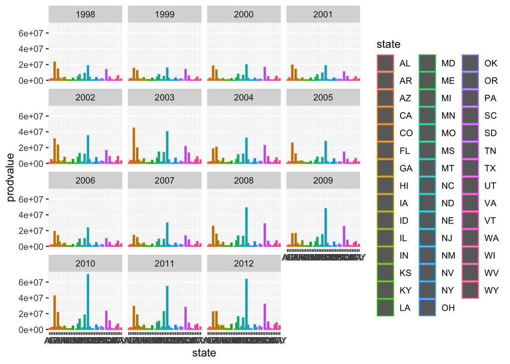

```r
ggplot(dat, aes(state, prodvalue, color = state)) +
geom_col(alpha = 0.9) +
facet_wrap(~year)
```

2nd attempt - still difficult to discern the lines at the bottom

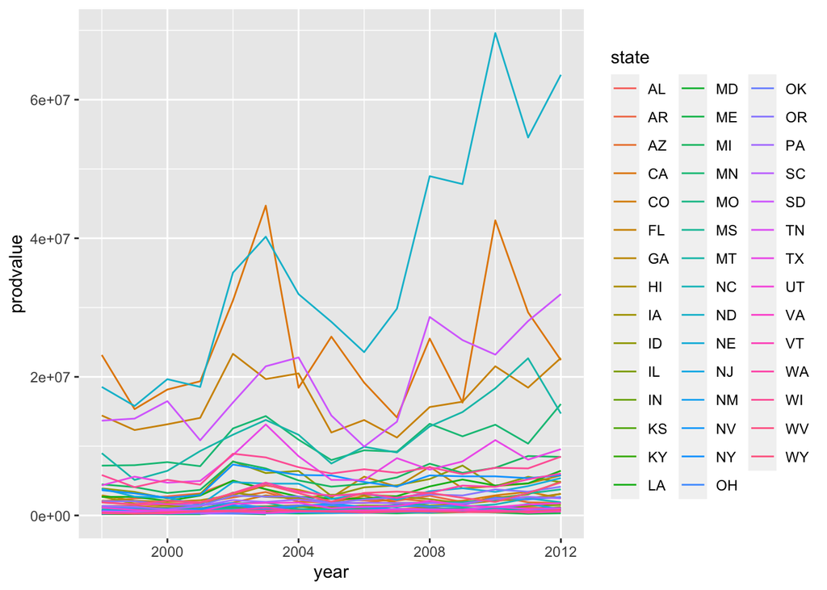

```r
ggplot(dat, mapping = aes(x = year, y = prodvalue, color = state)) +
    geom_line()
```

3rd attempt - Three states (WA, OR, CA) are highlighted in this version, but lose the color coding to discern all 44 states.

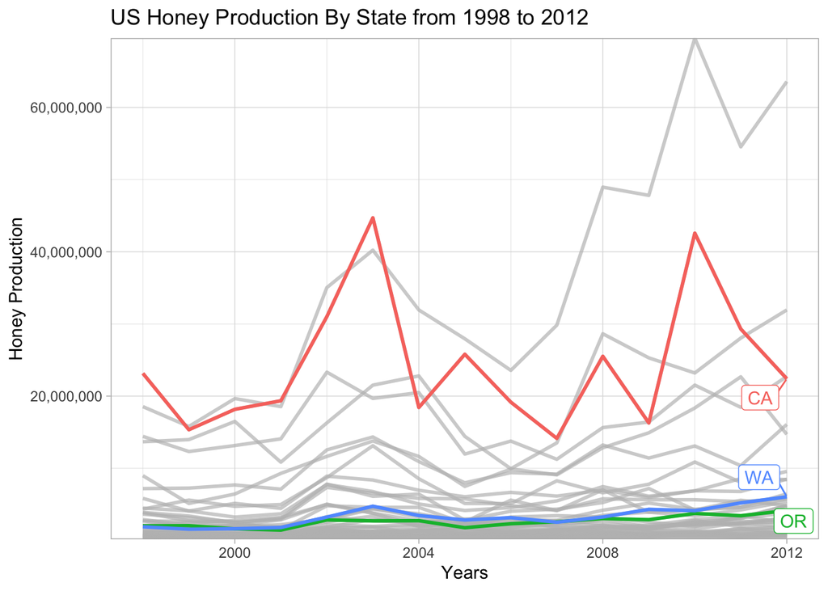

```r
ggplot(dat, mapping = aes(x = year, y = prodvalue)) +
    geom_line(aes(color = state), size = 1) +
  gghighlight(state == "OR" | state == "WA"| state == "CA") +
  labs(title = "US Honey Production By State from 1998 to 2012",
       x = "Years", y = "Honey Production") +
  scale_y_continuous(expand = c(0,0), labels = scales::comma ) +
  theme_light()
```

### 2. Reproduce the plot according to three different kinds of color blindness, as well as a desaturated version.

```r
# devtools::install_github("wilkelab/cowplot")
# install.packages("colorspace", repos = "http://R-Forge.R-project.org")
# devtools::install_github("clauswilke/colorblindr")

# library(colorblindr)
```

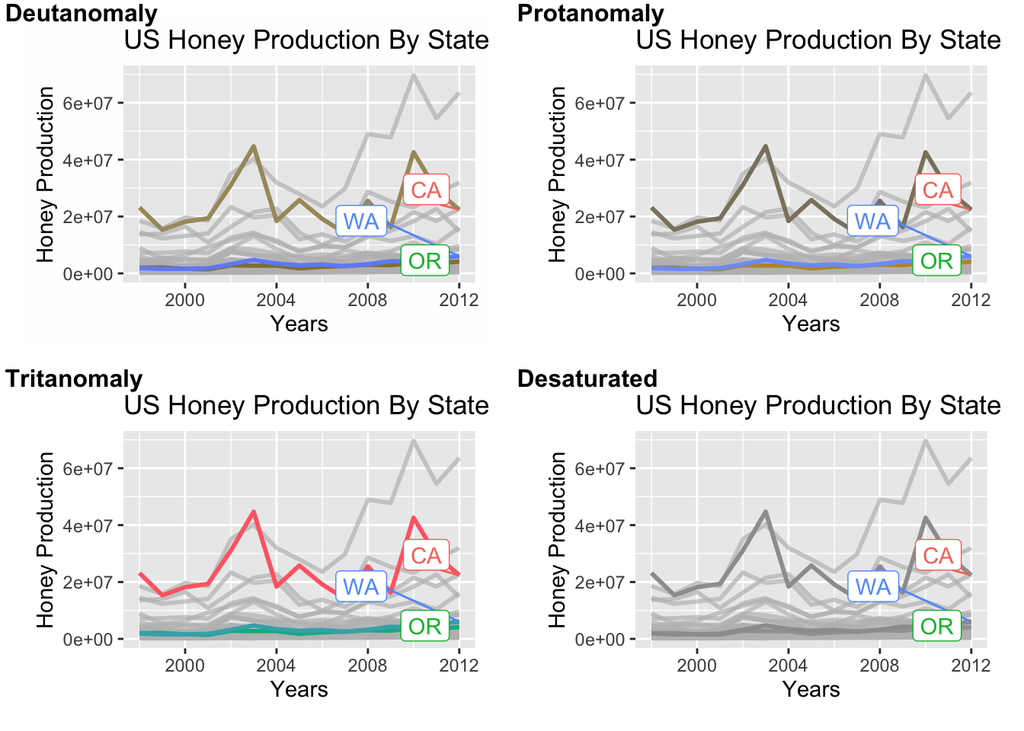

```r
cbt <- ggplot(dat, mapping = aes(x = year, y = prodvalue)) +
    geom_line(aes(color = state), size = 1) +
  gghighlight(state == "OR" | state == "WA"| state == "CA") +
  labs(title = "US Honey Production By State",
       x = "Years", y = "Honey Production")

colorblindr::cvd_grid(cbt)
```

### 3. Reproduce the plot using a color blind safe palette.

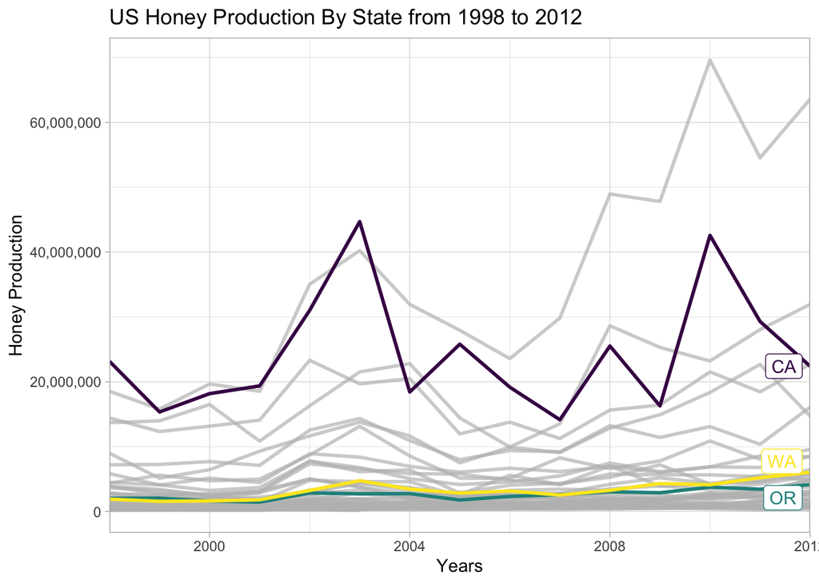

```r
cbud <- ggplot(dat, mapping = aes(x = year, y = prodvalue)) +
    geom_line(aes(color = state), size = 1) +
  scale_color_viridis(discrete = TRUE) +
  gghighlight(state == "OR" | state == "WA"| state == "CA") +
  scale_y_continuous(labels = scales::comma ) +
    scale_x_continuous(expand = c(0,0)) +
  labs(title = "US Honey Production By State from 1998 to 2012",
       x = "Years", y = "Honey Production") +
  theme_light()


cbud
```

### 4. Download the file here denoting the region and division of each state.

- Join the file with your honey file.
- Produce a bar plot displaying the average honey for each state (collapsing across years).
- Use color to highlight the region of the country the state is from.
- Note patterns you notice.

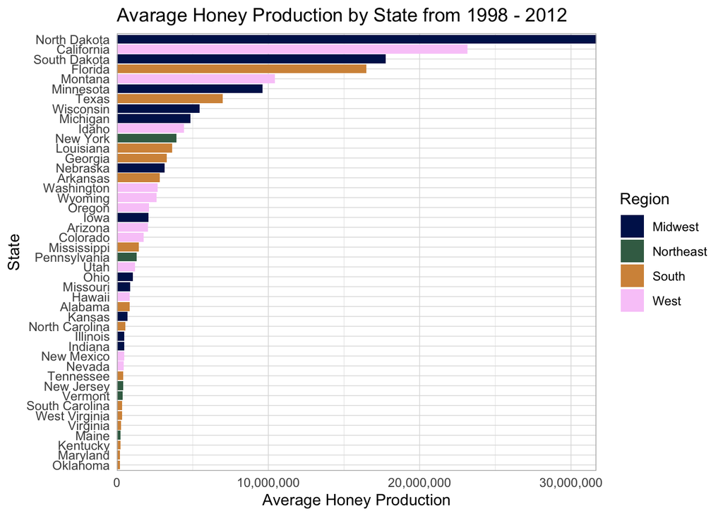

```r
region <- import(here("data", "us census bureau regions and divisions.csv")) %>%
  rename(state = `State Code`)

new <- full_join(region, dat)

  new %>%
    drop_na() %>%
    group_by(Region, State) %>%
    summarise(meanprod = mean(totalprod)) %>%
    ggplot() +
    geom_col(aes(meanprod, fct_reorder(State, meanprod), fill = Region)) +
      labs(x= "Average Honey Production",
       y = "State",
       title = "Avarage Honey Production by State from 1998 - 2012") +
    theme_light()+
    scale_x_continuous(expand = c(0,0), labels = scales::comma ) +
  theme (axis.ticks = element_blank()) +
    scico::scale_fill_scico_d()
```

Some emerging patterns:

- Midwest Region relatively has highest honey production in contrast with Northeast Region that has relatively low honey production.
- There is no consistent pattern for South and West Regions as the variation of honey production is quite large per state within these regions.

### 5. Create a heatmap displaying the average honey production across years by region (averaging across states within region).

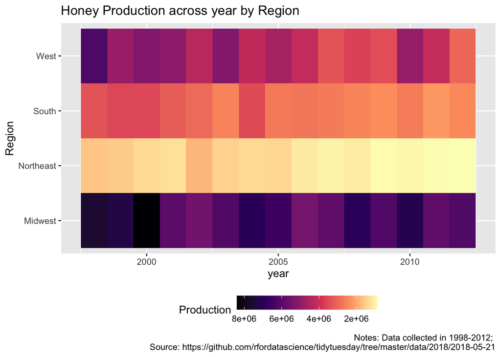

```r
new %>%
   drop_na() %>%
  group_by(year, Region) %>%
  summarise(meanprod = mean(totalprod)) %>%
  ggplot()+
  geom_tile(aes(Region, year, fill = meanprod))+
  scale_fill_viridis_c(option = "magma", trans = "reverse") +
  coord_flip() +
  theme(legend.position = "bottom",
        legend.direction = "horizontal",
        legend.key.size = unit(1, 'cm'),
        legend.key.height = unit(.5,"cm")) +
  labs(title = "Honey Production across year by Region",
       fill = "Production",
       caption = "Notes: Data collected in 1998-2012; \nSource: https://github.com/rfordatascience/tidytuesday/tree/master/data/2018/2018-05-21")
```

### 6. Create at least one more plot of your choosing using color to distinguish, represent data values, or highlight. If you are interested in producing maps, I suggest grabbing a simple features data frame of the US using the Albers projection by doing the following:

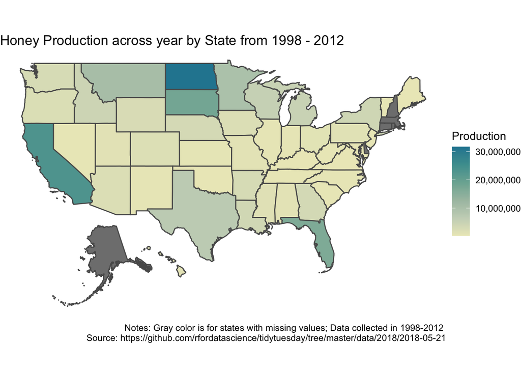

```r
map <- new %>%
    group_by(State) %>%
    summarise(meanprod = mean(totalprod))

remotes::install_github("hrbrmstr/albersusa")
library(albersusa)
us <- usa_sf()
join <- full_join(us, map, by=c("name" = "State"))

library(ggplot2)
ggplot(join) +
  geom_sf(aes(fill = meanprod)) +
  scale_fill_continuous_divergingx(palette = "Earth",  labels = scales::comma) +
  labs(title = "Honey Production across year by State from 1998 - 2012",
       fill = "Production",
       caption = "Notes: Gray color is for states with missing values; Data collected in 1998-2012 \nSource: https://github.com/rfordatascience/tidytuesday/tree/master/data/2018/2018-05-21") +
  theme_void()
```